# Calibration Experiment

## Part 1 SUS Questionnaire

We calculate a SUS-like score for a system where participants need to calibrate the intensity. In one condition, participants use a keyboard and in the other one they do it in VR using an avatar interacting with a virtual slider. We get the following distribution of scores for each conditions

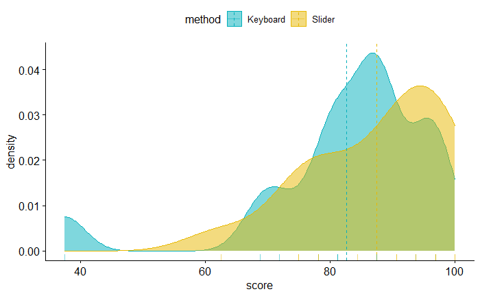

We attempt to find if the difference of the scores between the conditions is statistically significant by means of a paired T-test.

We need to verify the assumption that the observation (the difference between two set of values) is continuous and approximately normally distributed.

The distribution of the difference is as follows

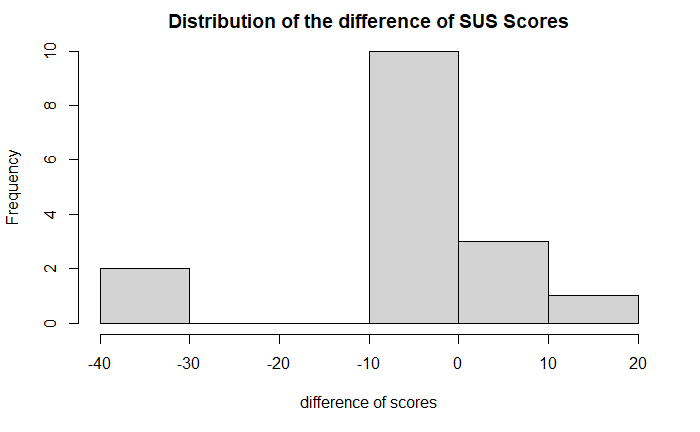

The previous distribution doesn’t look normal but we can verify this by performing a Shapiro-test and inspecting a Q-Q plot

| variable | statistic | p.value |
| --- | --- | --- |
| difference_t_test | 0.8659308 | 0.02357631 |

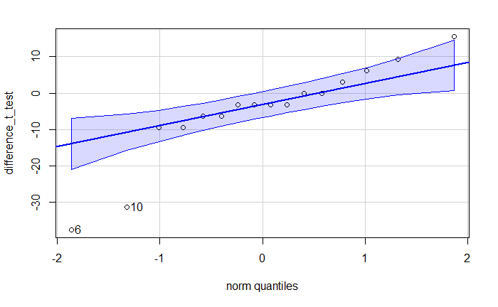

A p-value of 0.02 makes us reject the null hypothesis (normality of the data)

Given that we do not fulfill the assumptions, we perform a non-parametric test to see if the difference between the scores is statistically significant

```
Warning in wilcox.test.default(sus_keyboard$score, sus_slider$score, paired = TRUE,  :
  cannot compute exact p-value with ties
Warning in wilcox.test.default(sus_keyboard$score, sus_slider$score, paired = TRUE,  :
  cannot compute exact p-value with zeroes
```

```
    Wilcoxon signed rank test with continuity correction

data:  sus_keyboard$score and sus_slider$score
V = 32, p-value = 0.2061
alternative hypothesis: true location shift is not equal to 0
```

Wilcoxon-test warnings us about the similarity of the scores. In anyway, we obtain a p-value of 0.2 which tells us there is no evidence to reject the null hypothesis.

Non-parametric tests have less statistical power than parametric ones. We perform a paired T-test just to make sure we are not missing finding an effect.

```
    Paired t-test

data:  sus_keyboard$score and sus_slider$score
t = -1.4625, df = 15, p-value = 0.1642
alternative hypothesis: true difference in means is not equal to 0
95 percent confidence interval:
 -11.998964   2.233339
sample estimates:
mean of the differences
              -4.882812
```

Once again we get the same result that there is no statistically significant difference between the scores. This was kind of visible from the first plot showing the histogram of the scores and this is also reinforced by seeing the distribution of the scores using box and violin plots

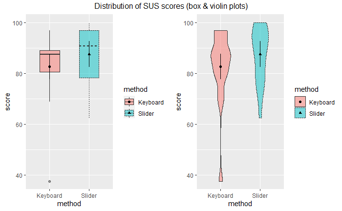

Given that the overall scores were similar, we start to analyze differences question by question. The SUS-like questionnaire was composed of 8 Likert-scale questions with answers in the range [0, 4] (Strongly Disagree, Strongly Agree).

We perform a two-sample Wilcoxon-test for each of the 8 questions and we get the following p-values:

```
[1] 0.520050527 0.395108069 0.298617674 0.427278906 0.824140896 0.371093370 0.005962079 0.607811259
```

Once again we get a warning telling us the similarity between the scores among conditions (hidden in the notebook). We can see most of the p-values are not significant except for the question number 7 which was regarding the speed of the method.

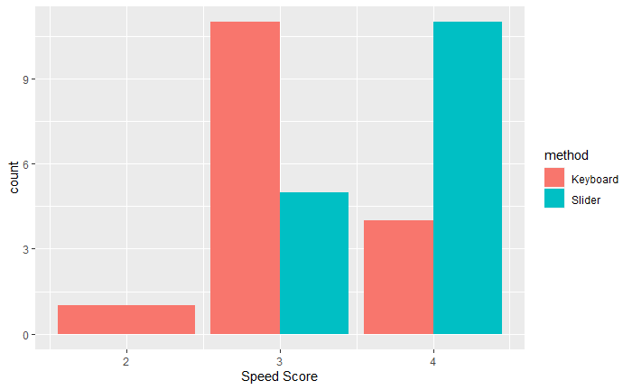

Here we can see most of the participants graded the keyboard condition with a lower score compared to the calibration in VR using the slider.

## Part 2 Analysis of In-Experiment Measured Data

As objective metrics, we recorded the calibration values (sensation and discomfort thresholds) obtained from the calibrations using each of the two proposed methods (keyboard, slider). Additionally, we recorded how long it took to calibrate using each of the methods.

To be more precise, we recorded three temporal metrics:

1. time since the beginning of the calibration until the last adjustment (interaction time)
2. time since the beginning of the calibration until the stimulation was turned off (sensation time)
3. time since the beginning of the calibration until the end of the calibration (calibration time)

In this section we analyze the resulting dynamic range (difference between the discomfort and sensation threshold) and the calibration time.

We start by seeing the distribution of the overall recorded values.

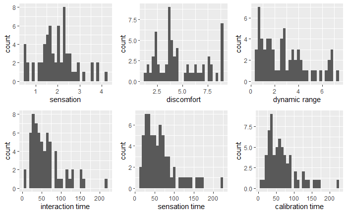

By comparing the last three plots, we can see the values and the distribution of the temporal variables are quite similar so we will analyze just the calibration time as a representative of the three.

For the calibration variables, we will focus only in the calibration dynamic range.

Our hypotheses are that the calibration in VR is faster and produces exactly the same calibration dynamic range as the keyboard condition, i.e participants are capable of setting the exact same values but faster.

Let’s start the analysis with the calibration time variable. Let’s see the distribution of the variable per condition

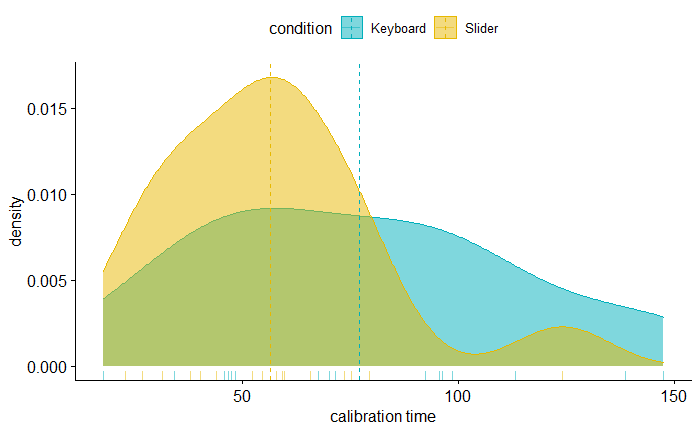

We see that the average calibration time using the keyboard method is longer than the slider method. We would like to test if that difference is statistically significant. We would like to try a parametric test but we need to know what the distribution of our data is.

We analyze the skewness-kurtosis of our data using a Cullen and Frey graph

```
summary statistics
------
min:  10.97256   max:  225.7337
median:  57.06508
mean:  66.67039
estimated sd:  42.48286
estimated skewness:  1.493533
estimated kurtosis:  5.520711
```

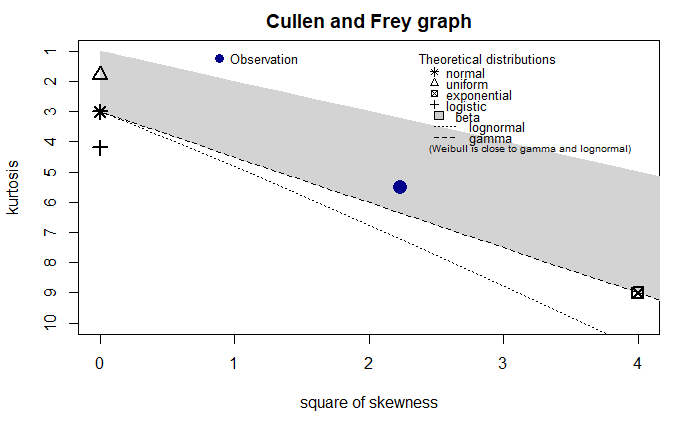

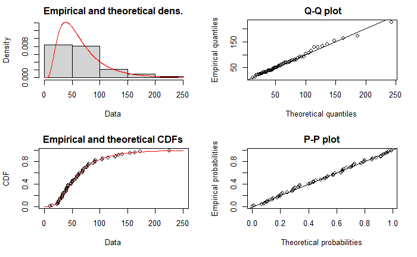

If our data is effectively log-normally distributed, then the logarithm of it will follow a normal distribution.

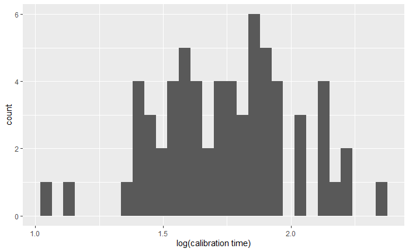

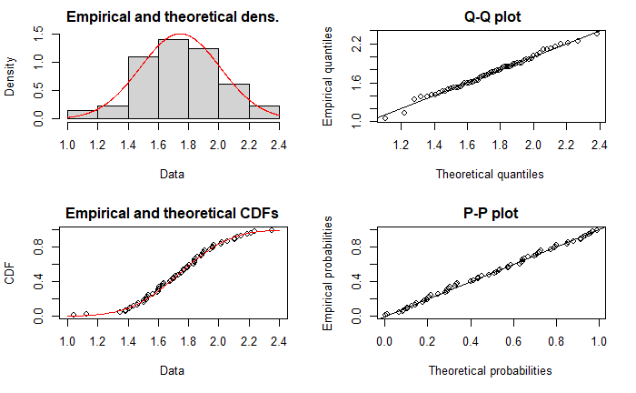

This is confirmed using a Shapiro-test for normality having strong evidence for that.

| variable | statistic | p.value |
| --- | --- | --- |
| measured_data$logFirstContactEndTrialElapsed | 0.991839 | 0.9501557 |

We will perform a paired T-test to compare the means between the two conditions. We will start by inspecting the distribution of the difference between observations. This is going to be performed in our transformed data (logarithmic).

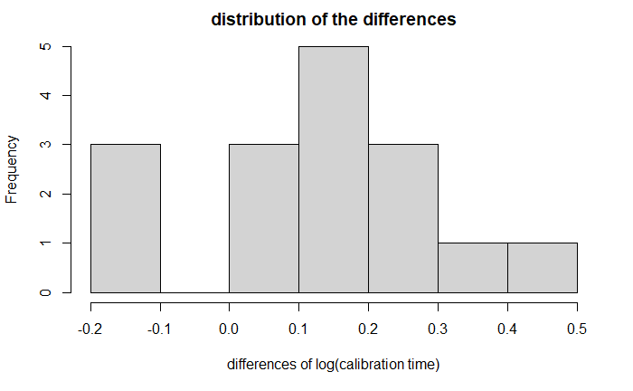

| variable | statistic | p.value |
| --- | --- | --- |
| difference_t_test | 0.9580483 | 0.6265531 |

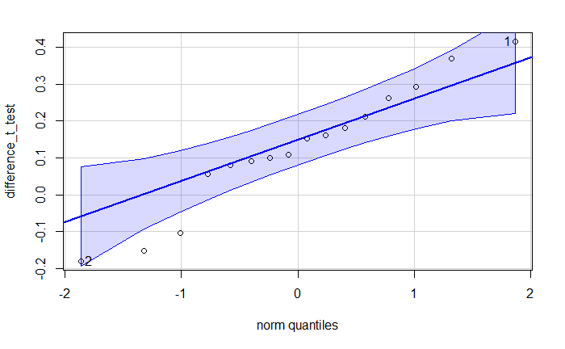

We have evidence that our data respects the normality assumption, so we can perform a paired T-test without any problem.

```
    Paired t-test

data:  grouped_data_keyboard$logFirstContactEndTrialElapsed and grouped_data_slider$logFirstContactEndTrialElapsed
t = 3.0069, df = 15, p-value = 0.008848
alternative hypothesis: true difference in means is not equal to 0
95 percent confidence interval:
 0.03726111 0.21870181
sample estimates:
mean of the differences
              0.1279815
```

We found that the difference of the means is statistically significant. This can also be observed visually by plotting the observations of the calibration time per participants.

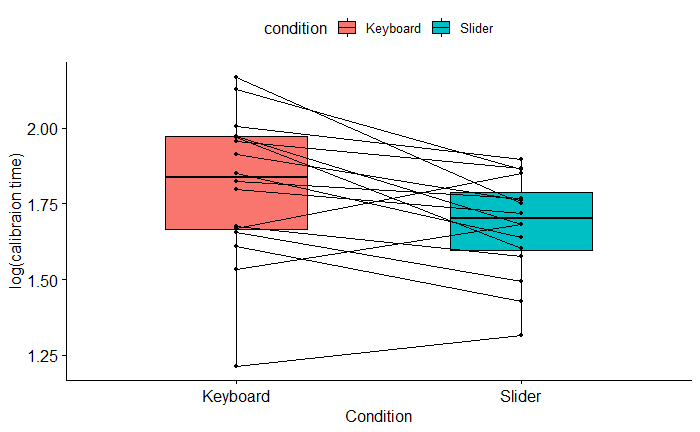

We can appreciate in the previous plot that most of the connecting lines go down, indicating that it took less time to calibrate using the slider for most of the participants.

We can perform a non-parametric test (two-sample Wilcoxon) in the non-transformed variable just to confirm our hypothesis.

```
    Wilcoxon signed rank exact test

data:  grouped_data_keyboard$firstContactEndTrialElapsed and grouped_data_slider$firstContactEndTrialElapsed
V = 112, p-value = 0.02139
alternative hypothesis: true location shift is not equal to 0
```

And once again we confirm the evidence with a p-value of 0.02.

We get a similar result if we run a 1-way ANOVA with repeated measures for the non-transformed data. For this test, we need to verify that the distribution of the residuals is normally distributed.

```
    Shapiro-Wilk normality test

data:  residuals
W = 0.95597, p-value = 0.2125
```

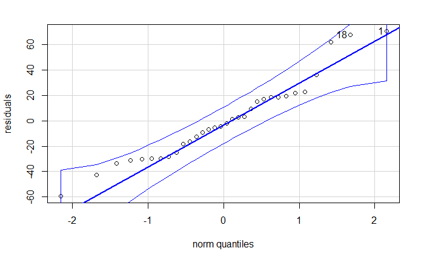

Our residuals are normally distributed and we can now perform the ANOVA test.

```
Anova Table (Type 3 tests)

Response: firstContactEndTrialElapsed
          num Df den Df   MSE      F     pes  Pr(>F)
condition      1     15 701.8 4.7397 0.24011 0.04586 *
---
Signif. codes:  0 ‘***’ 0.001 ‘**’ 0.01 ‘*’ 0.05 ‘.’ 0.1 ‘ ’ 1
```

In this case we get a p-value of 0.045 when comparing directly the calibration time using ANOVA.

Let’s end the analysis of the calibration time by plotting the distribution of the data using a box and a violin plots.

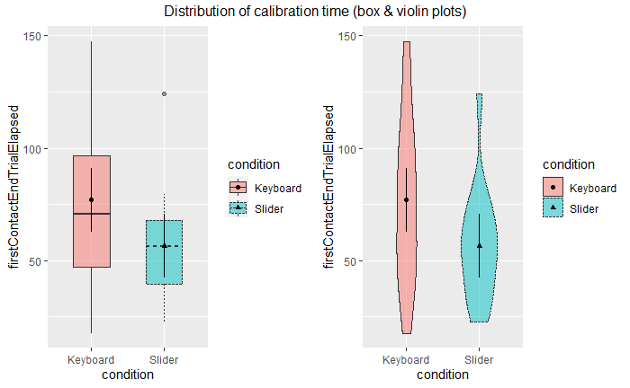

Here we can also appreciate how much more variability there is under the keyboard condition and if it weren’t by an observation marked as outlier in the slider condition, this difference would be greater.

Let’s now perform a similar analysis for the size of the dynamic range. Let’s remember that our hypothesis is that there won’t be any significant difference between both methods.

We will start by seeing the distribution per condition. And for the dynamic range

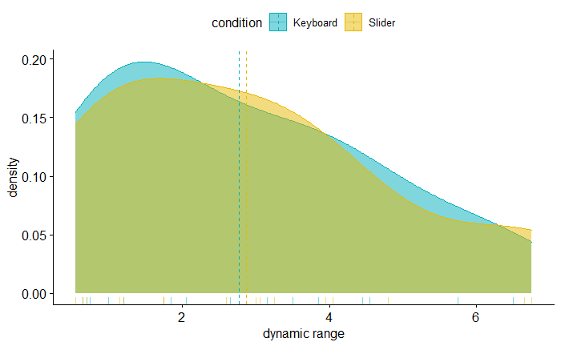

The values look quite similar and the distributions have a considerable overlap.

As in the previous analysis, we check for the normality of the data.

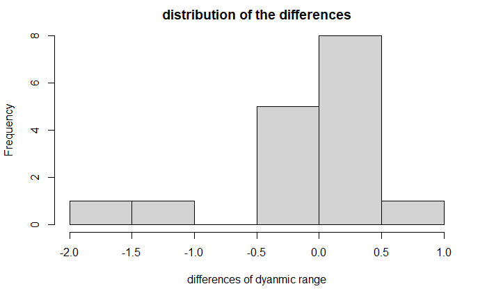

| variable | statistic | p.value |
| --- | --- | --- |
| difference_t_test | 0.7631377 | 0.0009186966 |

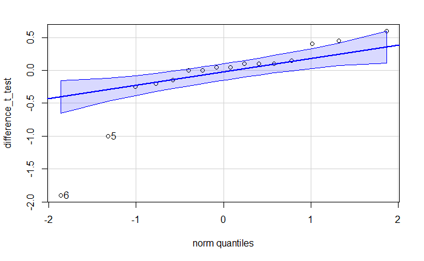

We proceed using the non-parametric two-sample Wilcoxon test.

```
Warning in wilcox.test.default(grouped_data_keyboard$dynamicRange, grouped_data_slider$dynamicRange,  :
  cannot compute exact p-value with ties
Warning in wilcox.test.default(grouped_data_keyboard$dynamicRange, grouped_data_slider$dynamicRange,  :
  cannot compute exact p-value with zeroes
```

```
    Wilcoxon signed rank test with continuity correction

data:  grouped_data_keyboard$dynamicRange and grouped_data_slider$dynamicRange
V = 54, p-value = 0.9499
alternative hypothesis: true location shift is not equal to 0
```

The non-parametric test tells us there is no statistically significant difference (it even warnings us about the similarity of the observations)

We will try in any way running a 1-way repeated measure ANOVA so let’s check the assumption of normality for the residuals

```
    Shapiro-Wilk normality test

data:  residuals
W = 0.91575, p-value = 0.01597

[1] 21 25
```

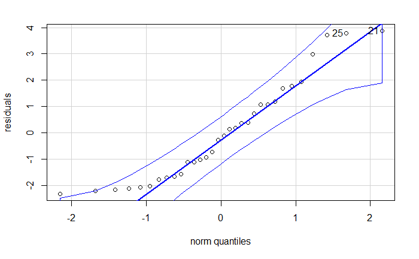

The distribution of the residuals is not normal and the p-value reported by ANOVA also says there is no significant difference.

```
Anova Table (Type 3 tests)

Response: dynamicRange
          num Df den Df     MSE      F      pes Pr(>F)
condition      1     15 0.17915 0.3925 0.025499 0.5404
```

All of this is reinforced by inspecting the distribution of the observations

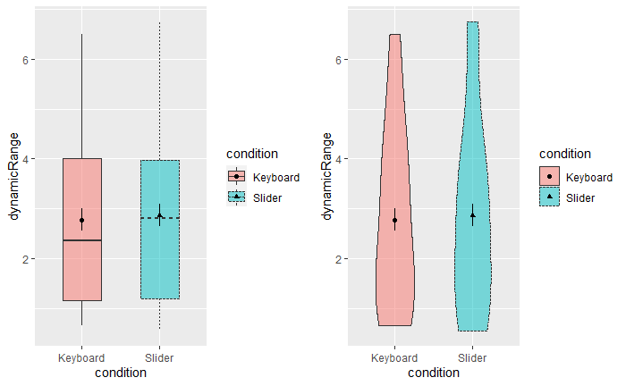

We see how they are practically identical, therefore our hypothesis seems right.

The observations look pretty much one-to-one, i.e. for a given participant, its dynamic range didn’t change based on the keyboard/slider condition

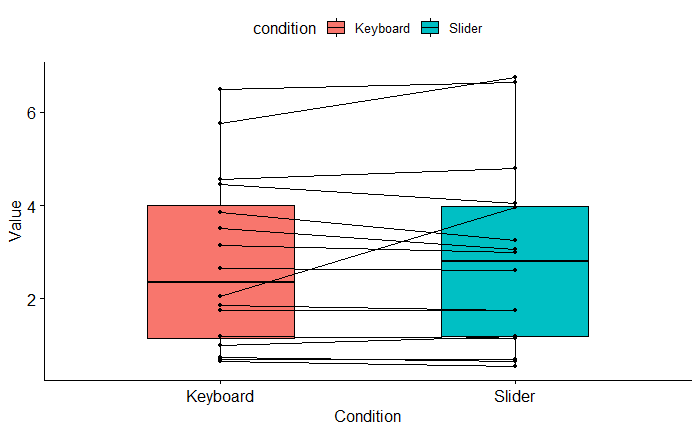